# U.S.-Australia Economic Dashboard

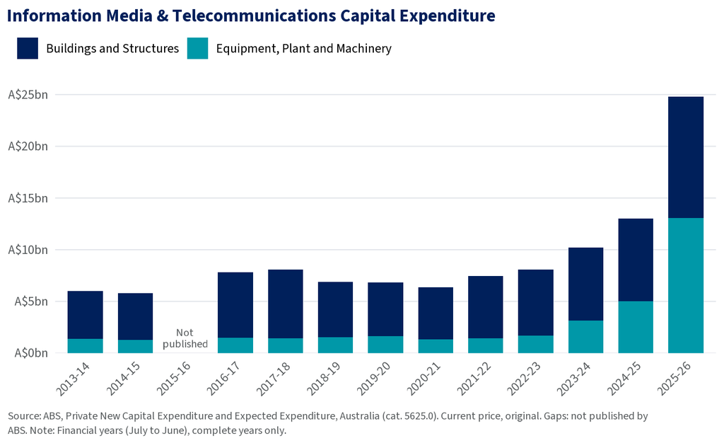

**Commercial Buildings**

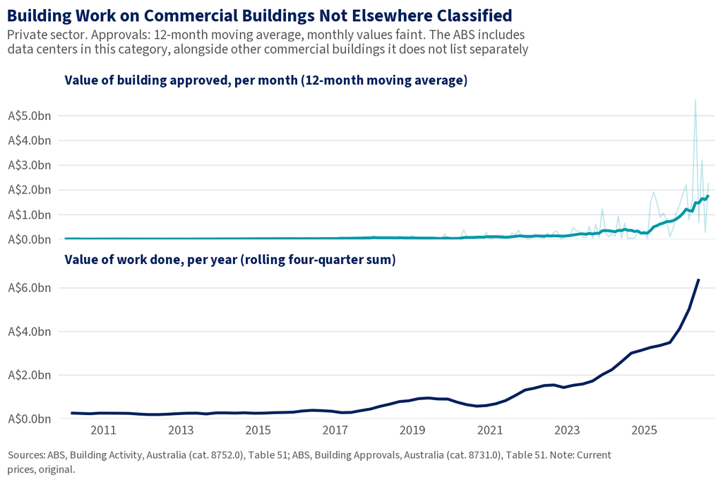

**Computer Imports**

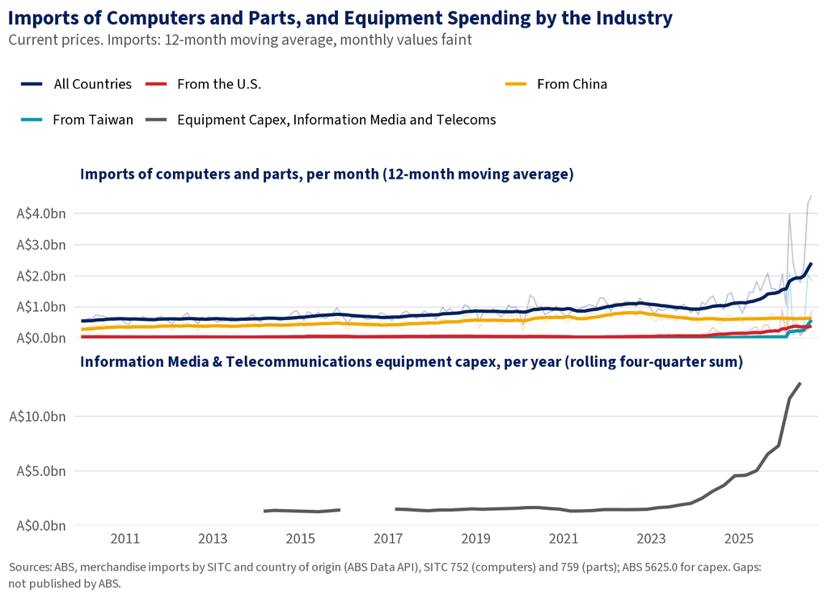

U.S. Intellectual Property in Australia

**Patents**

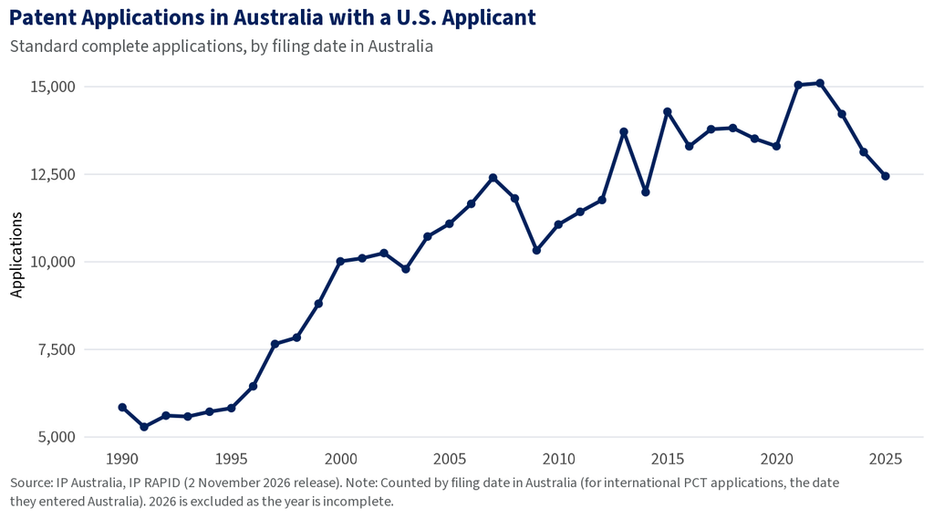

**U.S. Share of Patents**

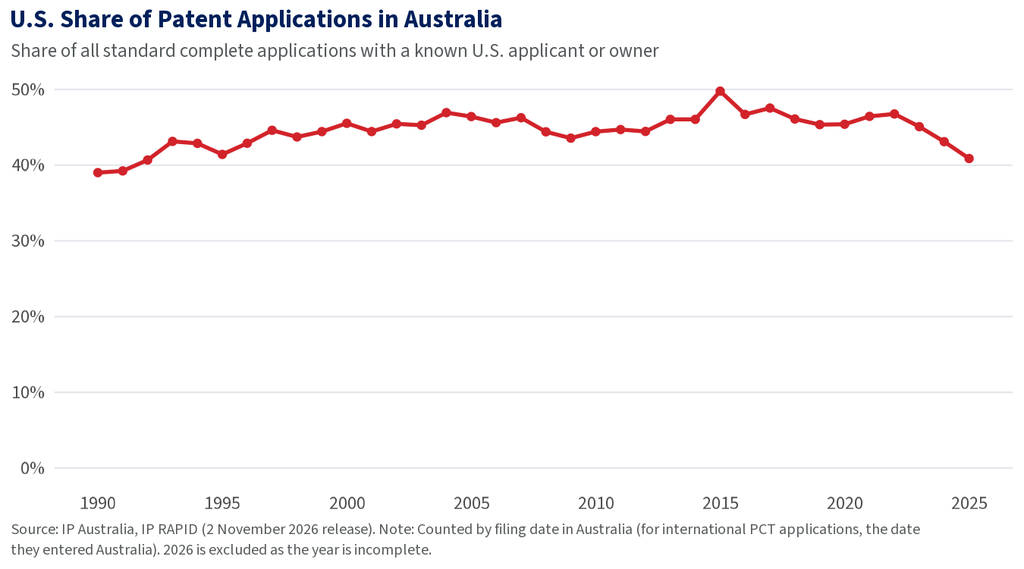

**Patents by Sector**

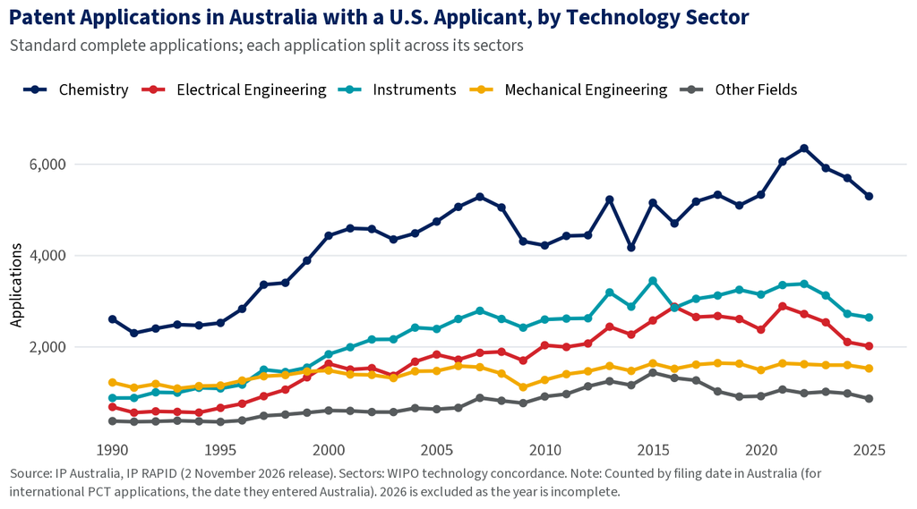

**Patents by Field**

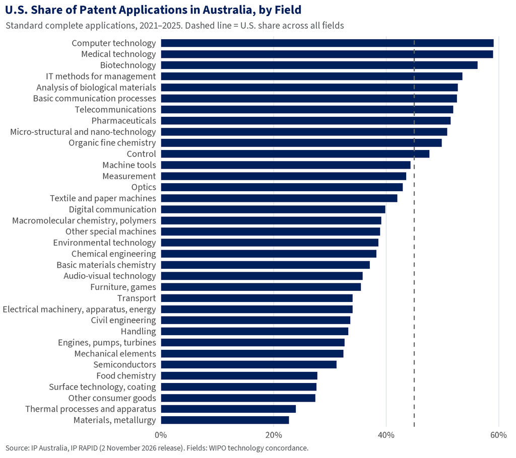

**Trademarks**

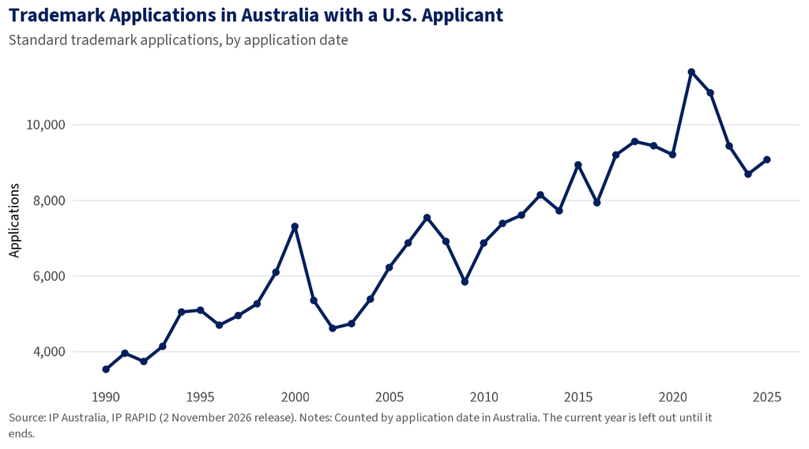

**U.S. Share of Trademarks**

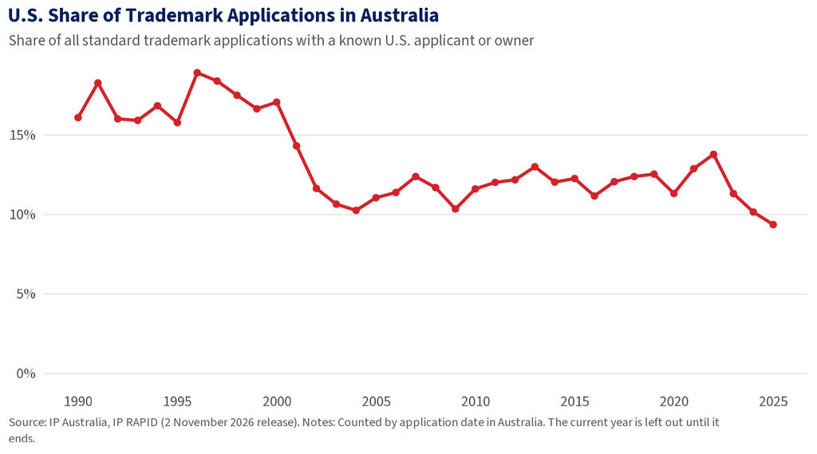

**Trademarks by Sector**

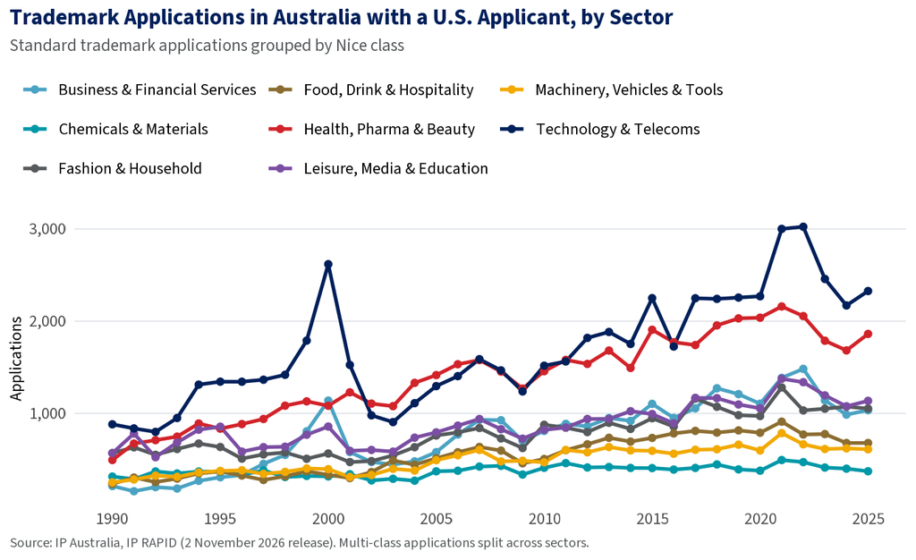

**Trademarks by Class**

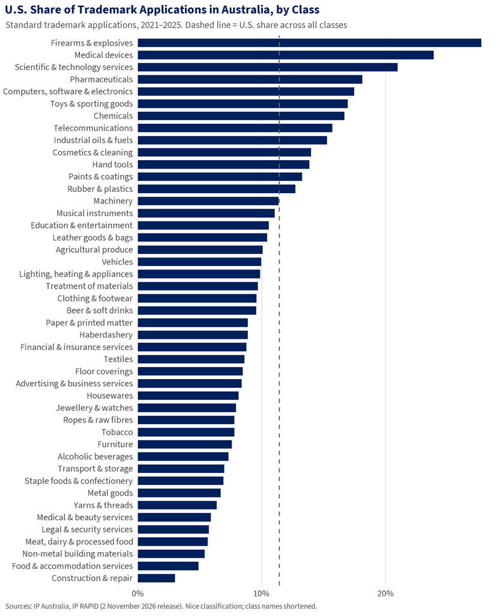

Joint U.S.-Australian Filings

**Patents over Time**

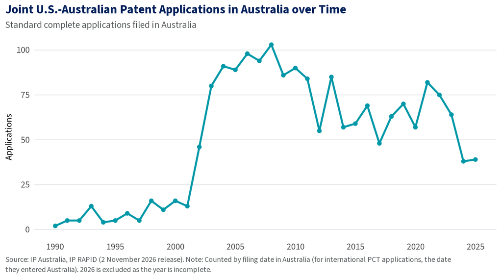

**Patents by Field**

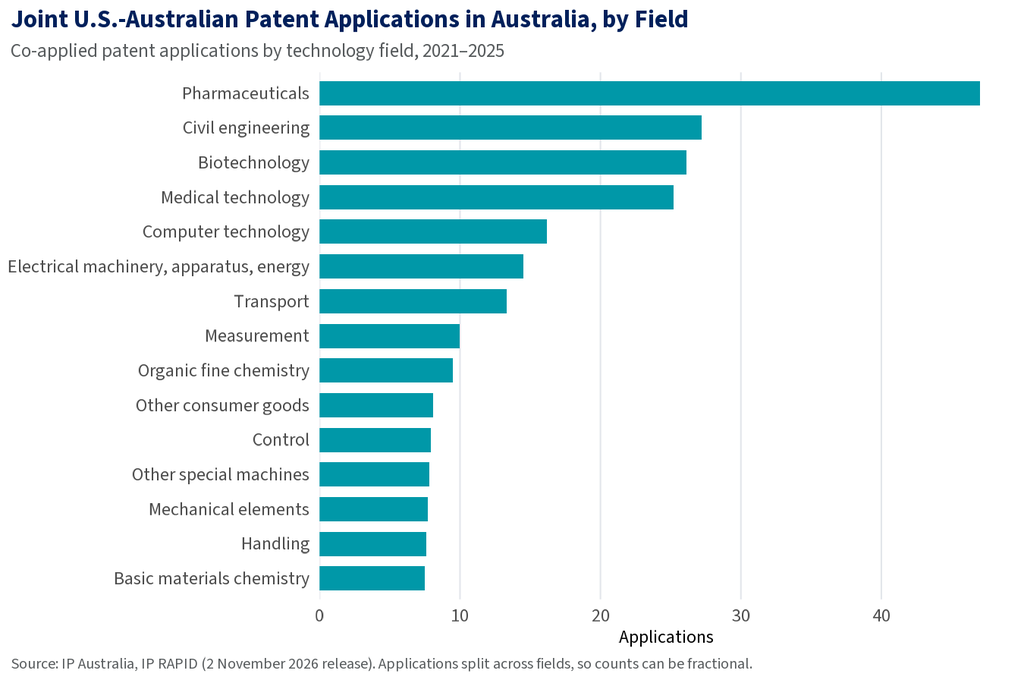

**Trademarks over Time**

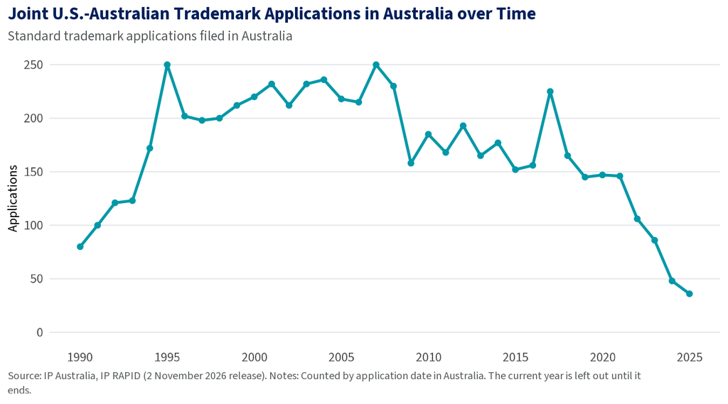

**Trademarks by Class**

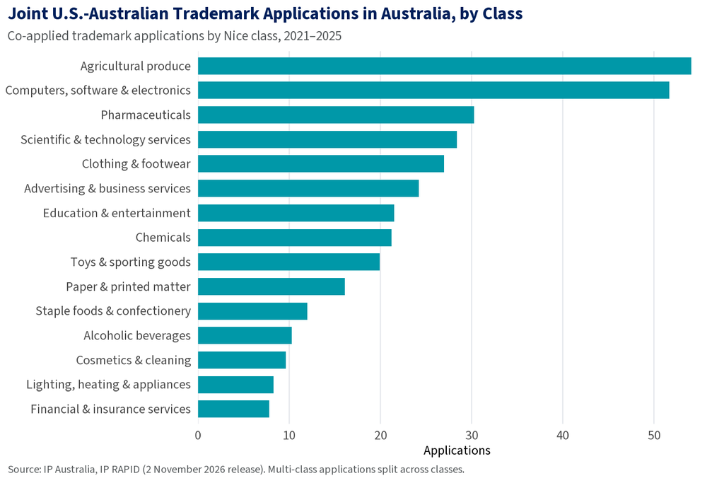

Australia's Critical Minerals

**Map**

Critical Minerals Map: Hover and Click Each Location for Details

[interactive chart not shown]

**Australia’s Global Share**

Australia’s Share of World Production and U.S. Import Reliance

| Titanium (rutile) | 44.4% | #1 | 71.4% | #1 | 88% | 11% | Not a major source |
| --- | --- | --- | --- | --- | --- | --- | --- |
| Zirconium | 33.3% | #1 | 78.6% | #1 | <25% | 35% | Not a major source |
| Lithium | 31.7% | #1 | 22.7% | #2 | >50% | Not a major source | Not a major source |
| Bauxite | 22.0% | #2 | 12.8% | #2 | >75% | 8% | Not a major source |
| Alumina (refined) | 11.3% | #2 | n/a | n/a | 71% | 6% | Not a major source |
| Lead | 10.7% | #2 | 35.8% | #1 | 33% | 13% | Not a major source |
| Zinc | 8.5% | #3 | 26.7% | #1 | 73% | Not a major source | Not a major source |
| Titanium (ilmenite) | 8.3% | #4 | 34.7% | #1 | 88% | 11% | Not a major source |
| Manganese | 8.0% | #4 | 34.1% | #1 | 100% | 10% | Not a major source |
| Rare earths | 7.4% | #3 | 7.4% | #3 | 67% | Not a major source | 71% |
| Tin | 4.1% | #7 | 9.5% | #5 | 77% | Not a major source | Not a major source |
| Silver | 3.8% | #9 | 14.9% | #3 | 77% | Not a major source | Not a major source |
| Copper | 3.2% | #8 | 10.2% | #2 | 57% | Not a major source | Not a major source |
| Tantalum | 2.0% | #6 | n/a | #2 | 100% | 14% | 22% |
| Cobalt | 1.2% | #5 | 14.2% | #2 | 79% | Not a major source | Not a major source |
| Antimony | 1.2% | #7 | 5.5% | #6 | 91% | Not a major source | 55% |
| Tungsten | 1.2% | #8 | 12.1% | #2 | >50% | Not a major source | 26% |
| Nickel | 1.2% | #8 | 17.9% | #2 | 41% | 8% | Not a major source |

Click a column heading to sort; click again to reverse. Bars show each value out of 100%. Source: USGS, Mineral Commodity Summaries 2026 data release (doi:10.5066/P1WKQ63T); 2025 values are USGS estimates. Alumina is refinery output; all others are mine output. Titanium import share covers all titanium mineral concentrates. Import reliance for lead, zinc and tin is for refined metal, for rare earths compounds and metals, and for zirconium ores and concentrates; ‘>’ and ‘<’ are USGS bounds. ‘Not a major source’: USGS does not list that country among the main U.S. suppliers. Import shares are for the same form as the import reliance figure (e.g. refined metal; for zirconium, ores and concentrates). Reserves are as estimated by USGS; n/a where USGS gives no world total. World totals for lithium and bauxite exclude U.S. output, which USGS withholds. Some countries’ output is withheld for antimony; ranks count only published figures. Download data (CSV)

End-Use Family

Lifecycle Stage

Economy in Latest Year

**Australia vs U.S. States**

[figure not shown]

**Relative Size**

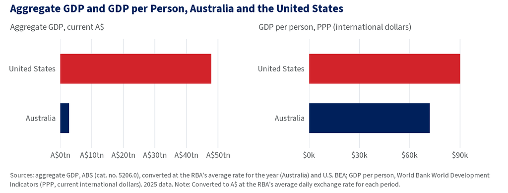

**OECD Comparison**

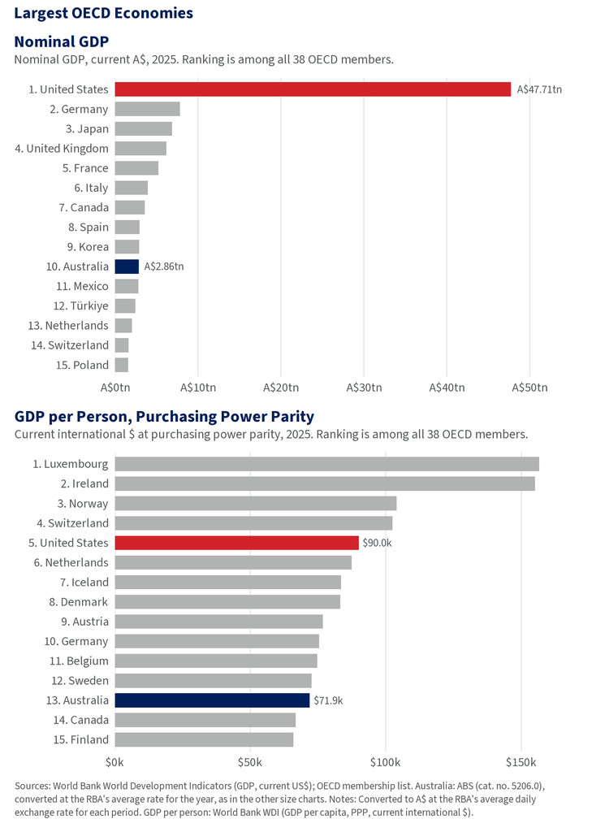

**Industry Composition**

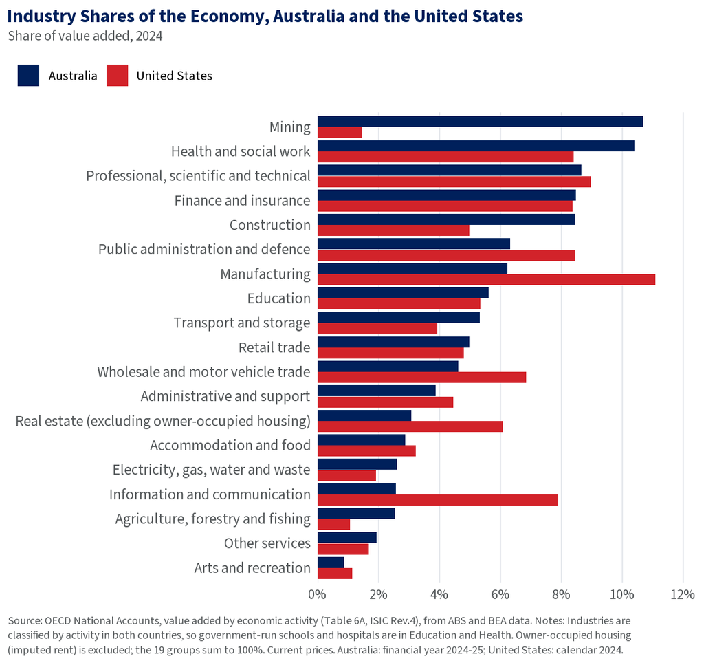

Economy over Time

**GDP**

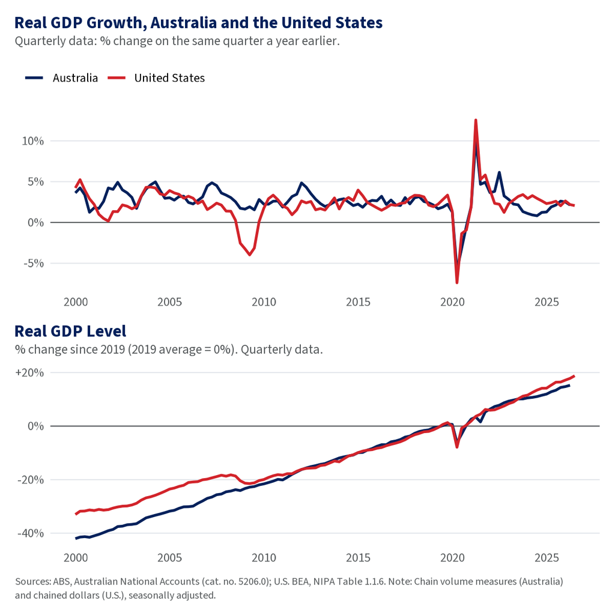

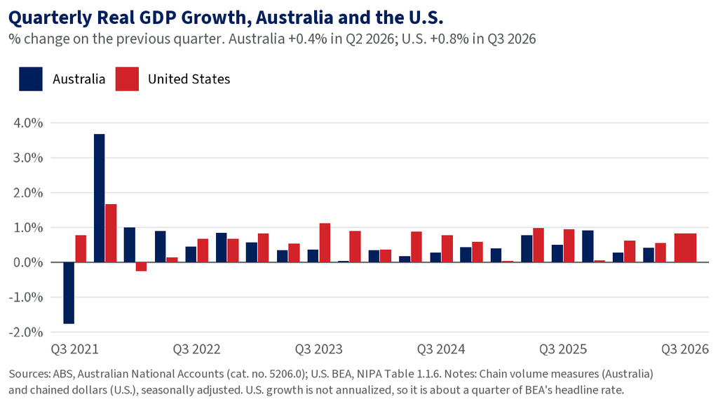

**GDP per Person**

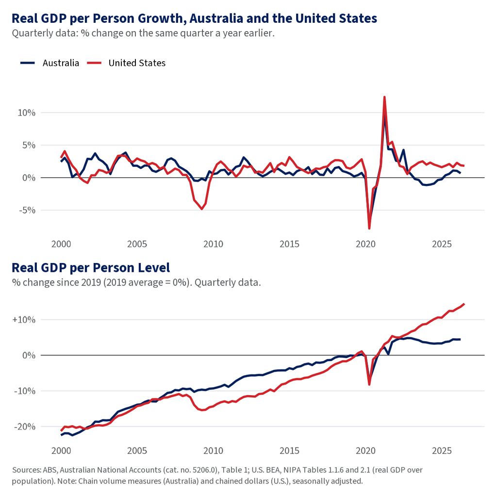

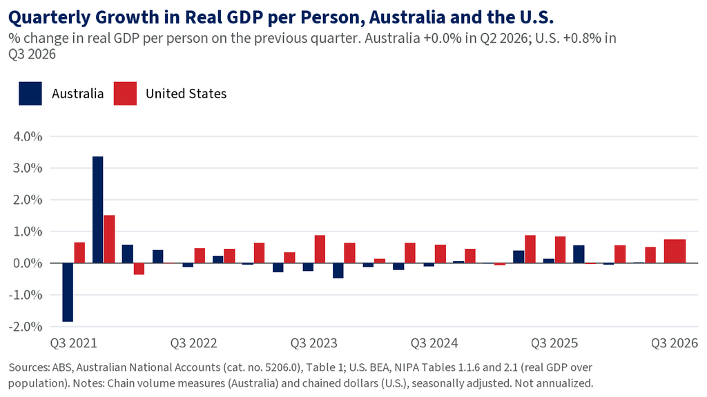

**Productivity**

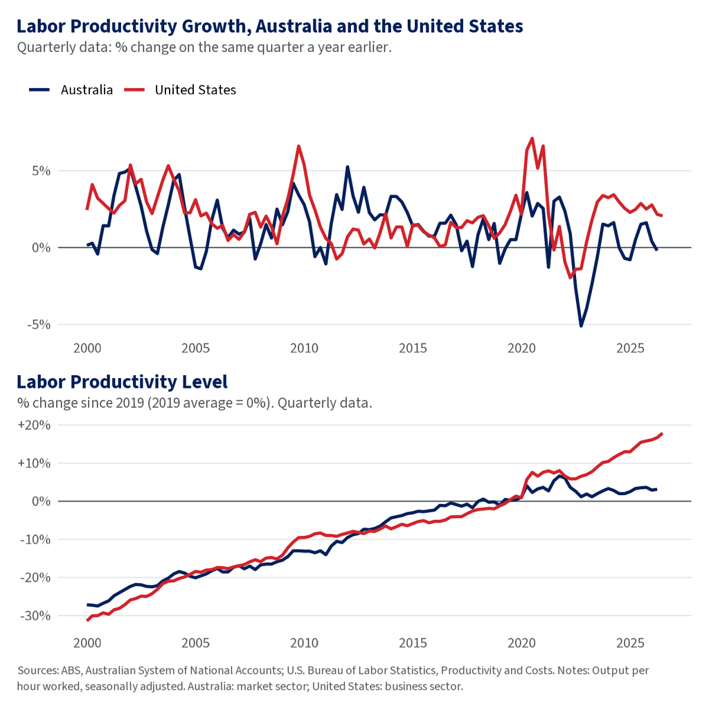

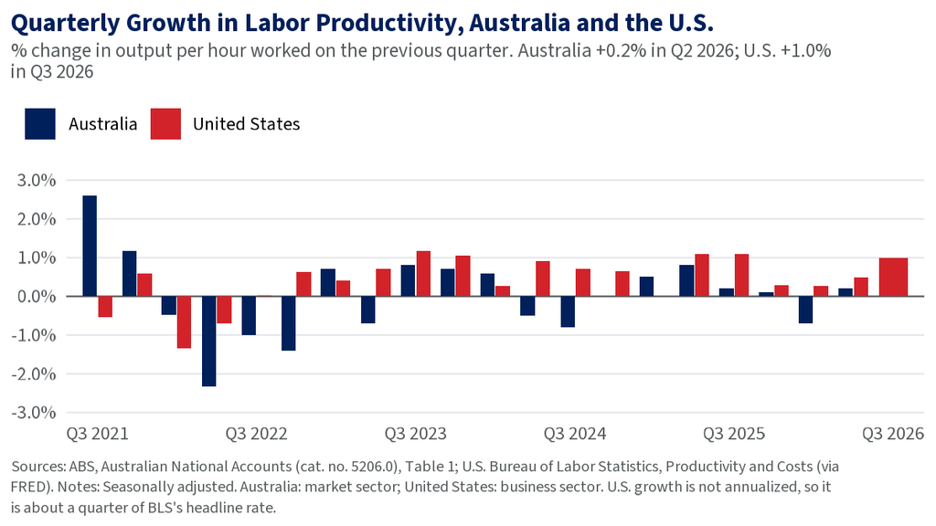

Energy Security, Costs and Prices

**Energy Security**

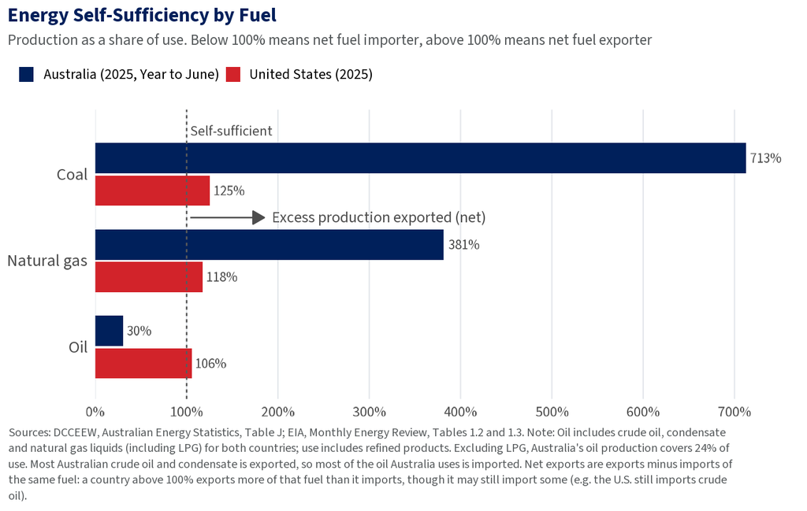

**Wholesale Prices**

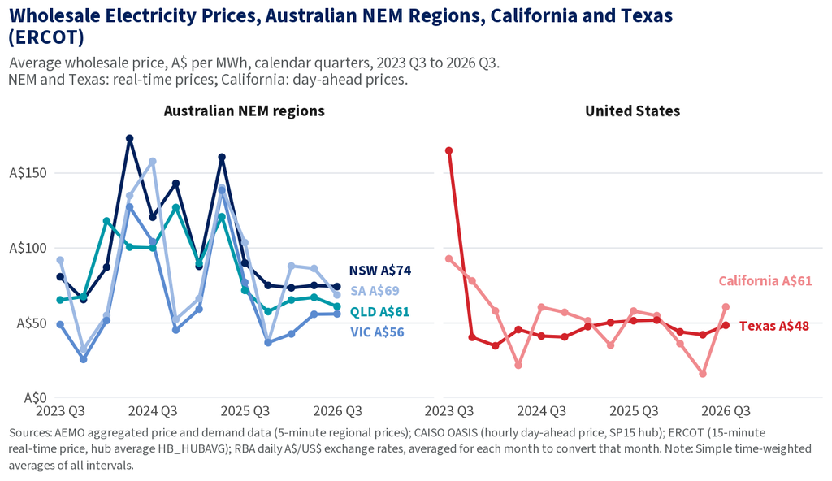

**Cost of New Solar and Wind**

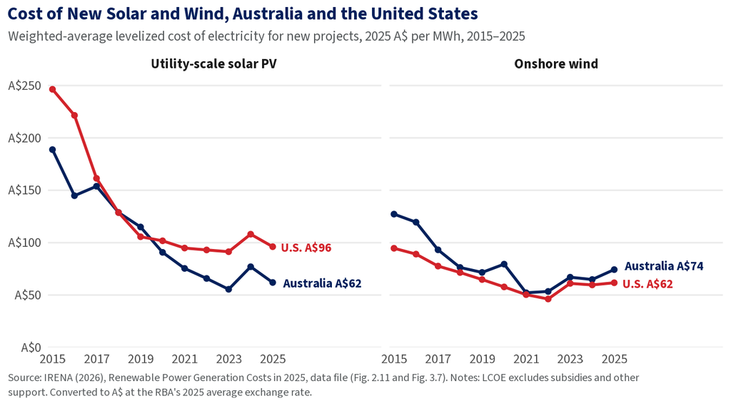

**Clean Tech Imports**

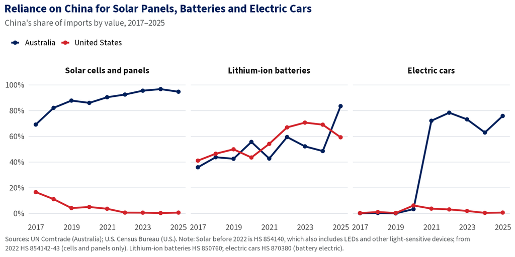

Electricity Mix

**Source**

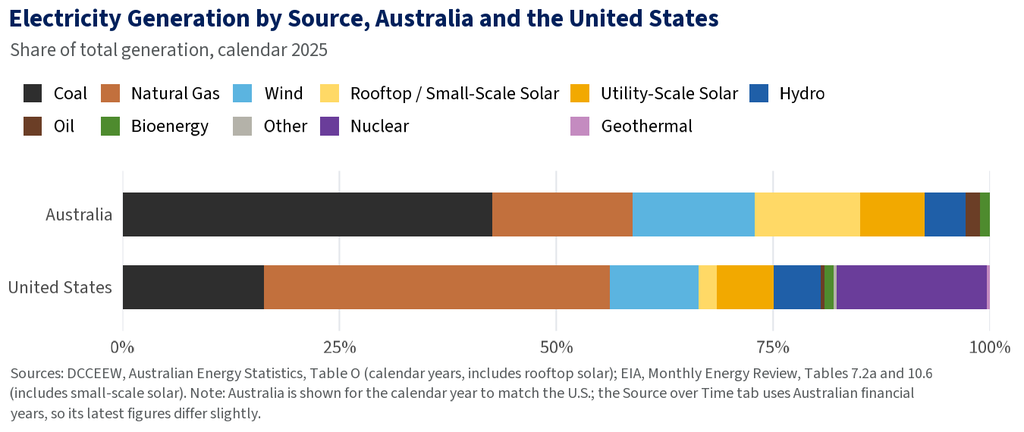

**Source over Time**

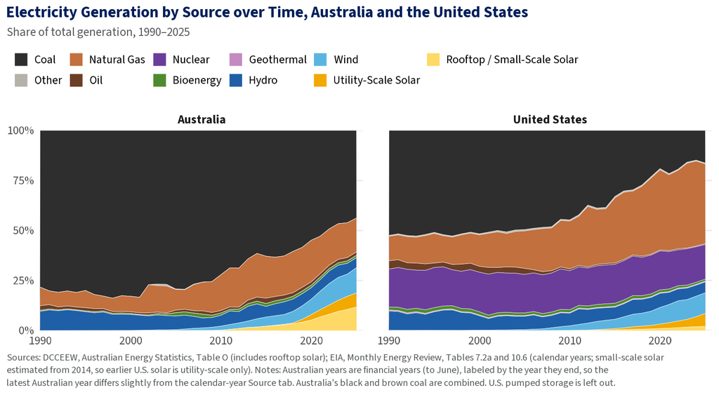

**By State**

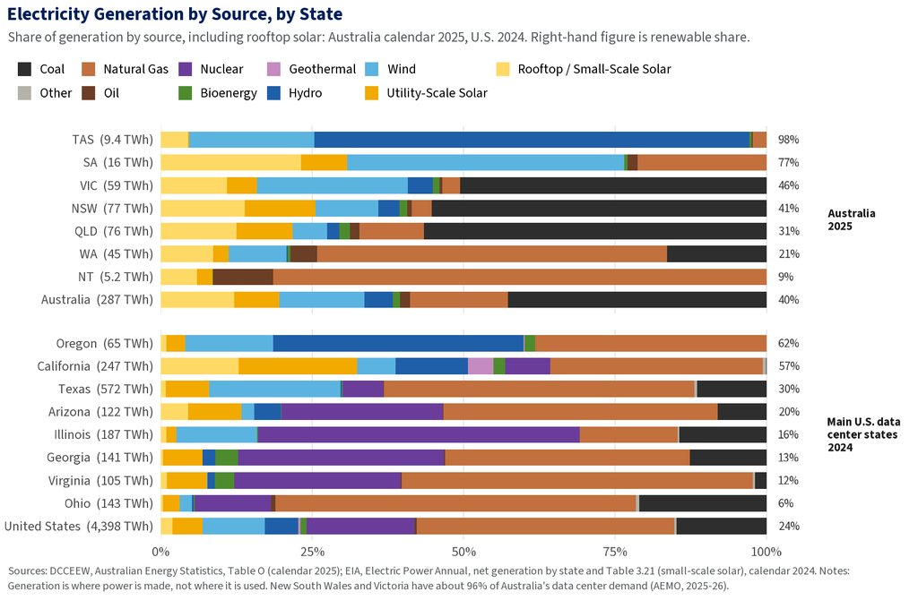

**Carbon-Free by Technology**

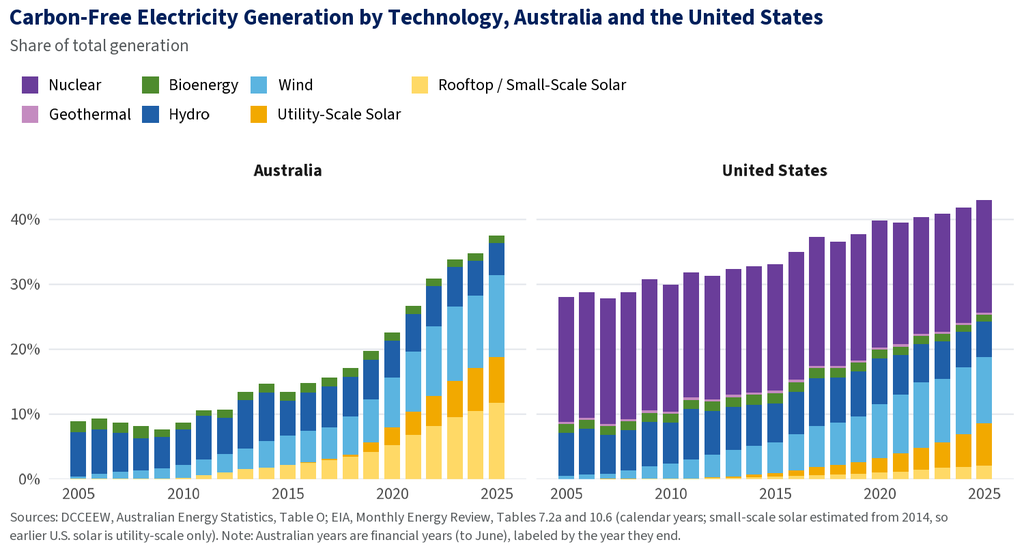

**Targets**

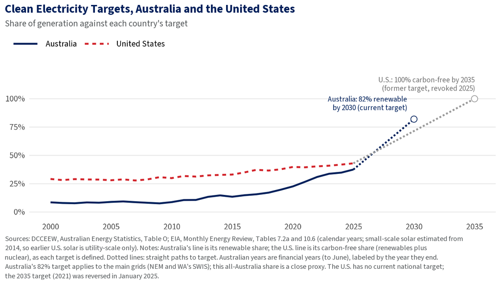

Australia's Research Strengths

**Share of World Research**

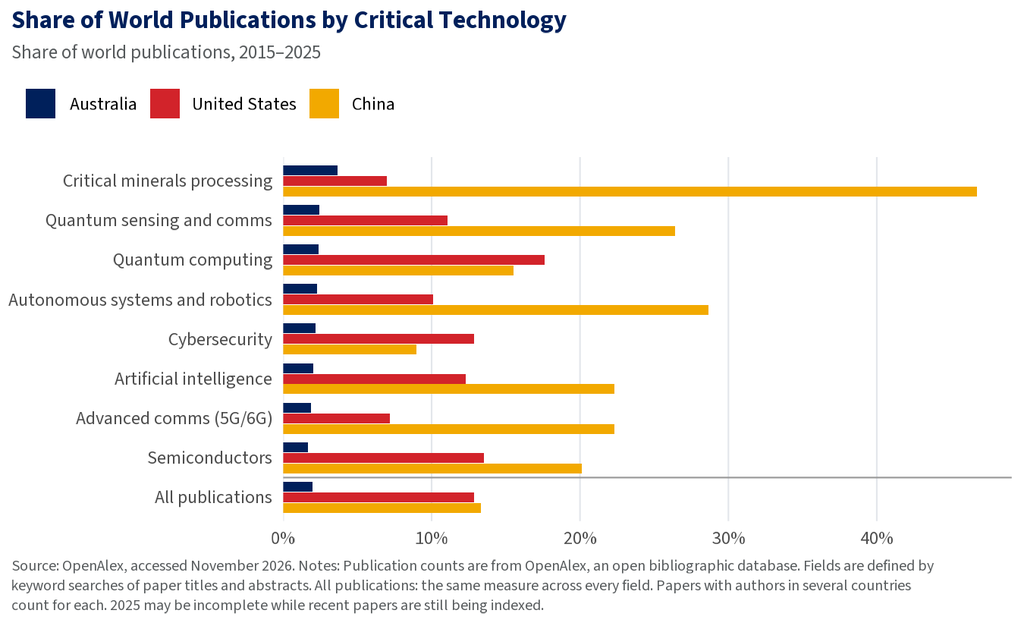

**Share over Time**

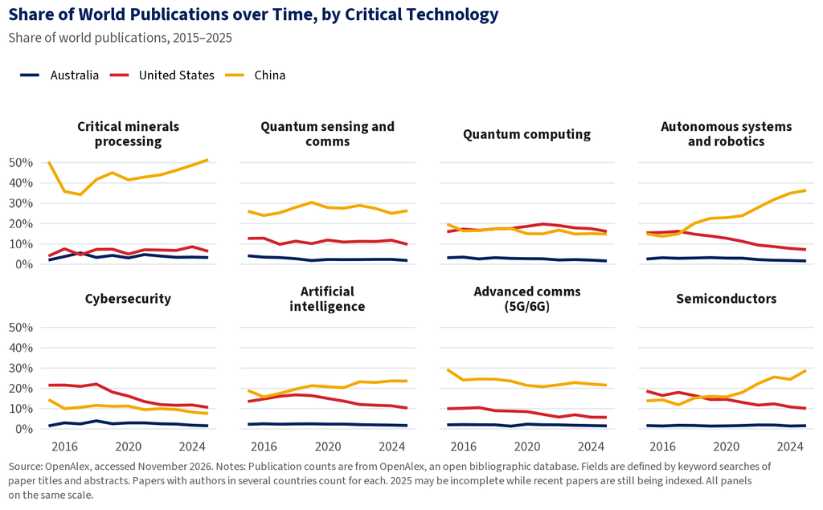

**Quality vs Volume**

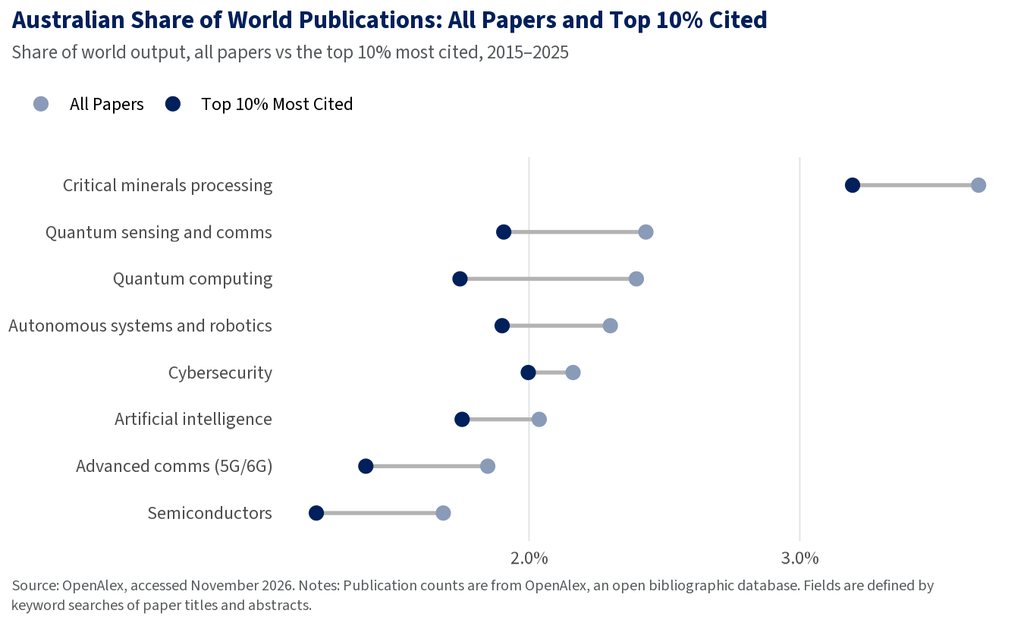

**Institutions**

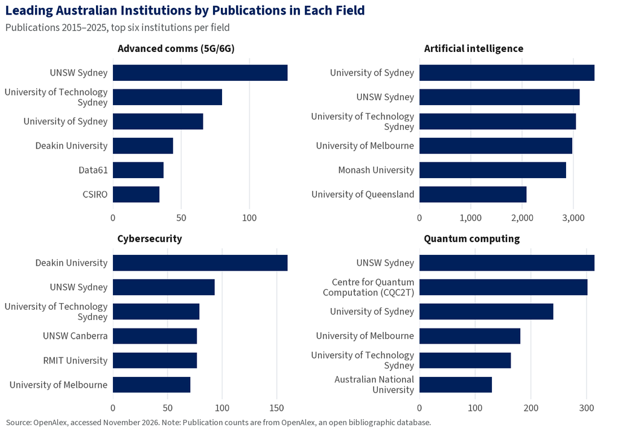

Collaboration and Capability

**Collaboration: U.S. vs China**

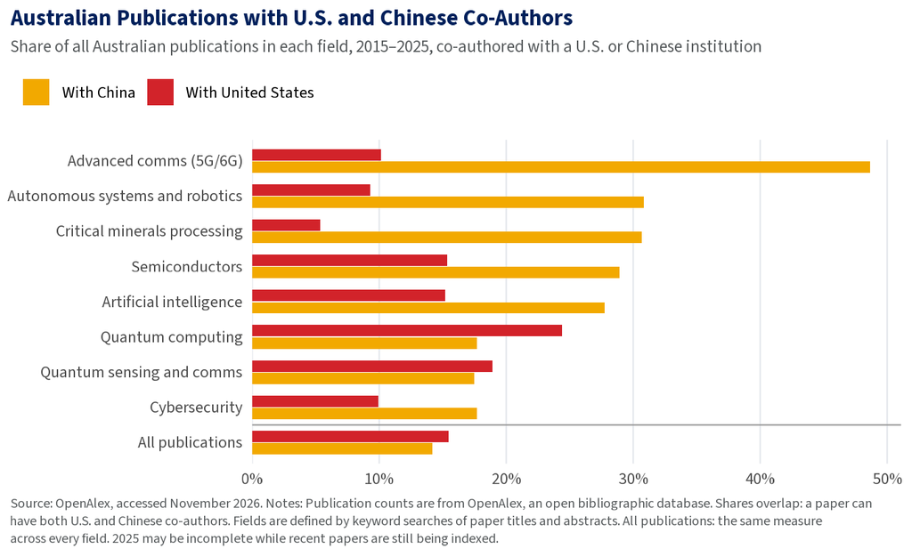

**AI Models**

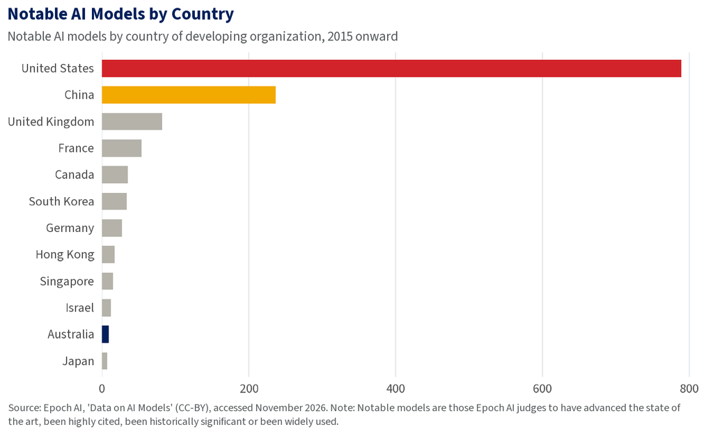

**R&D Intensity**

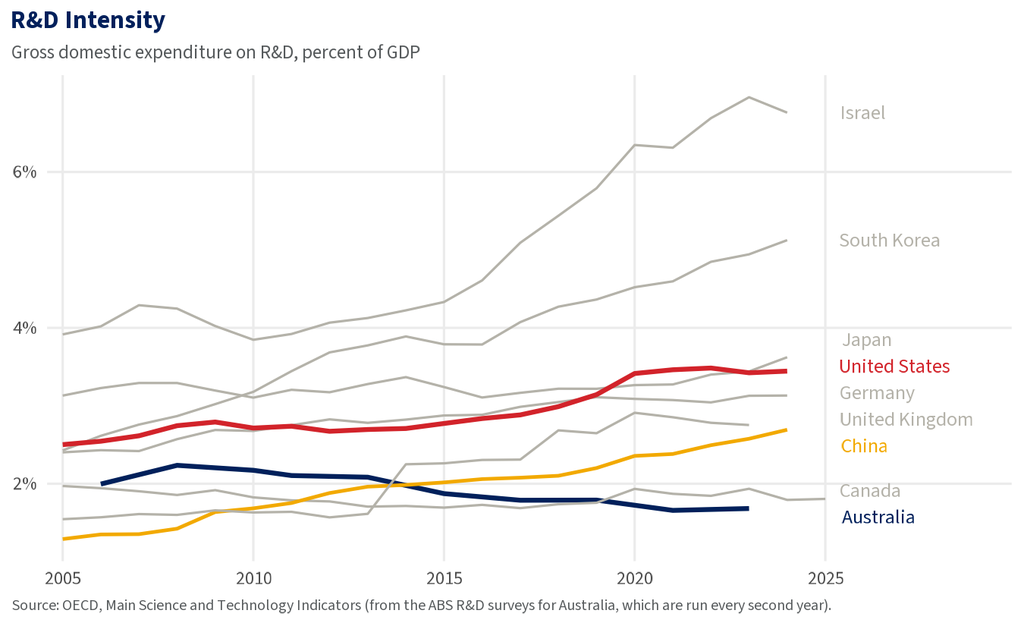

Australians in the United States

**Skilled Visas**

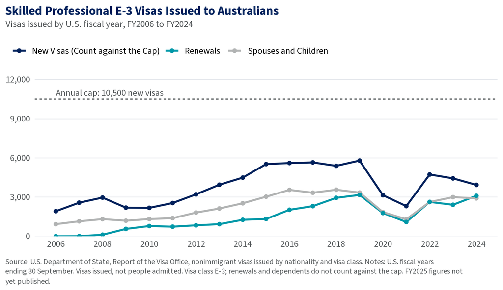

**Skilled Visas over Time**

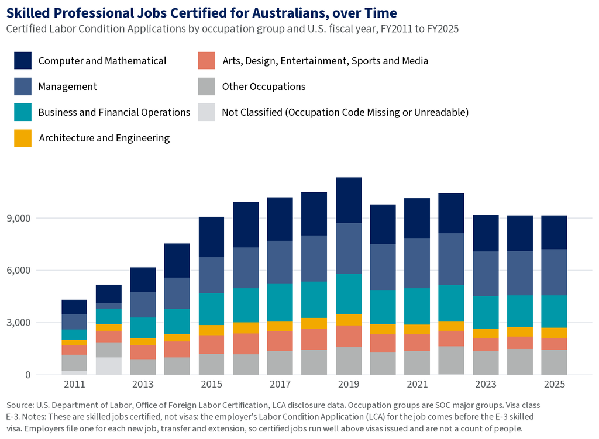

**Skilled Visas by Employer/City**

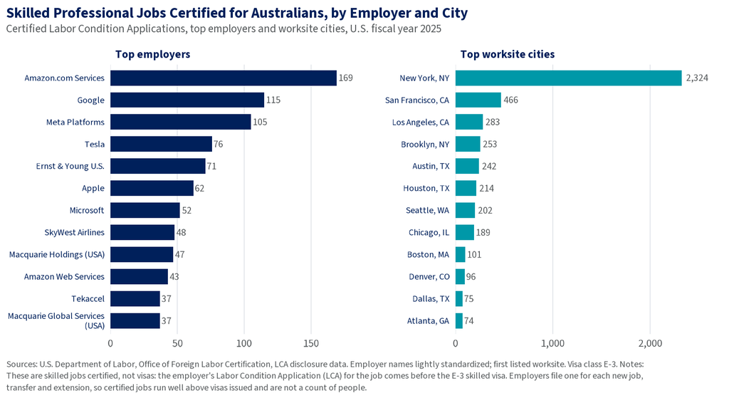

**Students and Exchange**

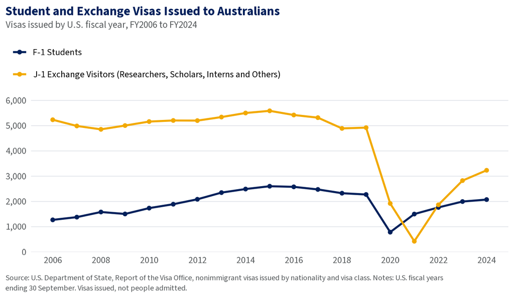

Americans in Australia

**Net Migration**

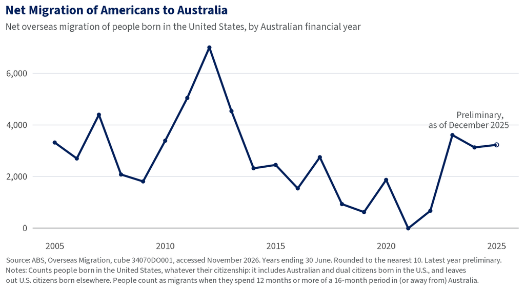

**Skilled Visas by Occupation**

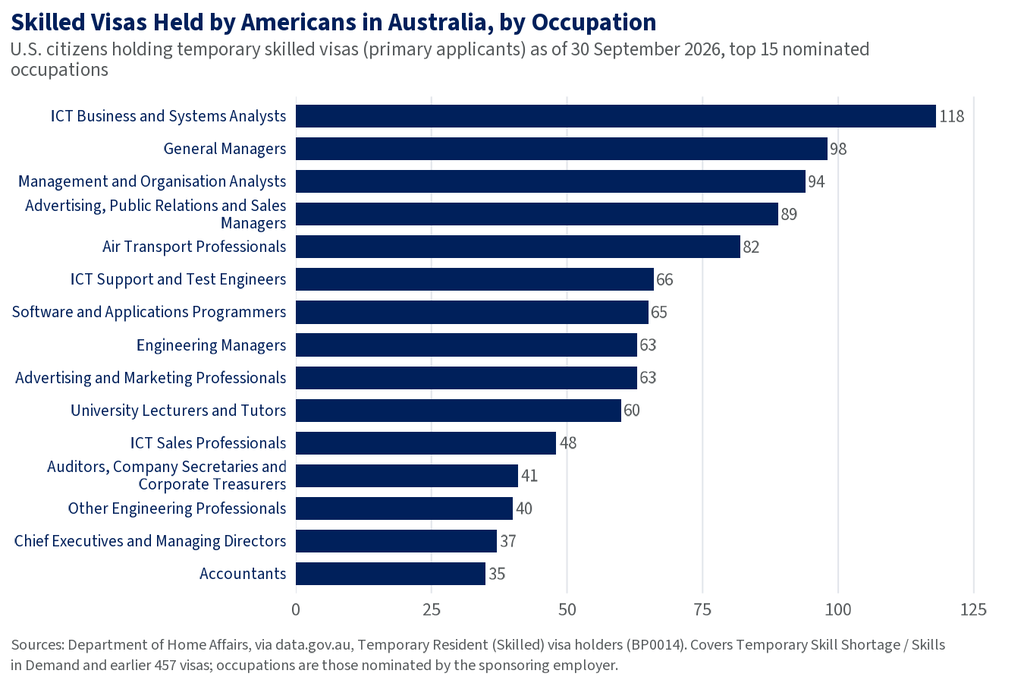

**Temporary Visas by Type**

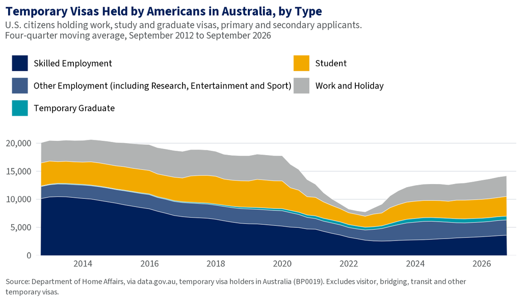

Two Countries at a Glance

Land Area

Almost exactly the same size

Australia7,682,300 km²

United States7,653,005 km²

Coastline

Australia’s coastline is 29% longer

Australia25,760 km

United States19,924 km

Population

The U.S. has 12 times the people

Australia27.9 million

United States341.8 million

Land area for the U.S. is the contiguous 48 states and DC; coastline and population are for the whole country. Population: Australia March 2026, U.S. July 2025. Sources: CIA World Factbook (final edition, 2026); U.S. Census Bureau; ABS.

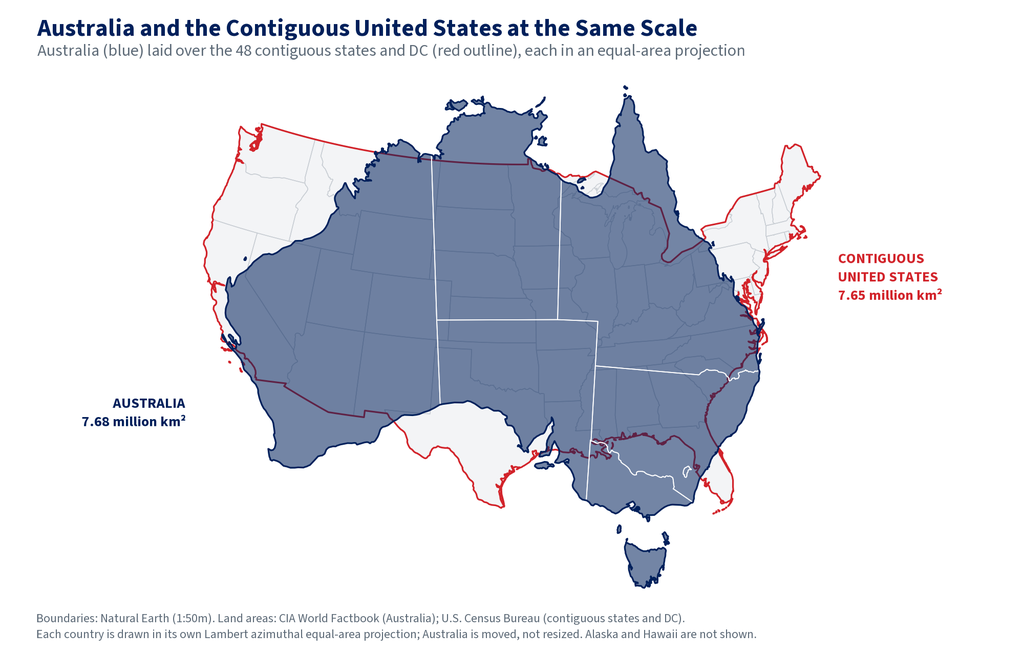

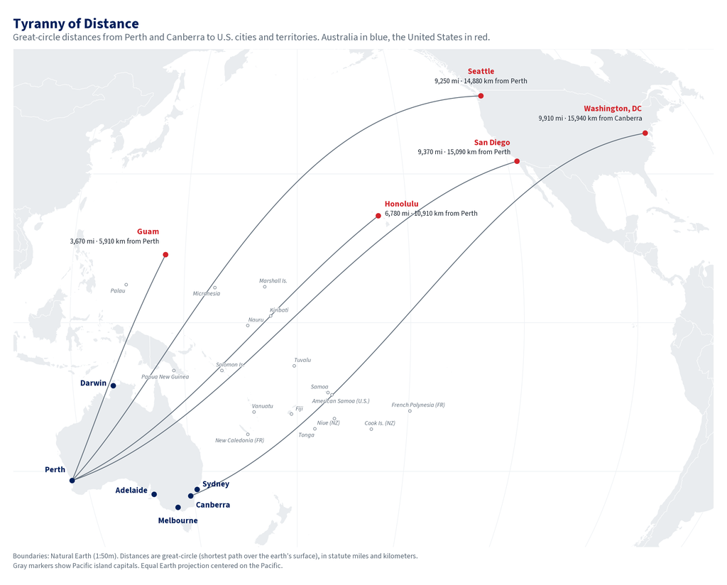

## Methodology, Sources and How to Cite

The economic side of the U.S.-Australia alliance, from investment and trade to critical minerals, energy, and technology, is increasingly central to the relationship, yet the data needed to understand it are scattered across more than 20 institutions in two countries. This dashboard brings that information together in one place, offering a regularly updated view built entirely from official U.S. and Australian data. Every chart is refreshed each quarter and can be downloaded with its data from the links under the chart.

### Authors and Contact

- [Angelina Bruno](https://www.csis.org/people/angelina-bruno), Michael and Deborah Thawley Fellow, Australia Chair (ABruno@csis.org)
- [John Augé](https://www.csis.org/people/john-auge), Associate Director, Australia Chair (JAuge@csis.org)
- [Charles Edel](https://www.csis.org/people/charles-edel), Australia Chair and Senior Adviser (CEdel@csis.org)
- [Kathryn Paik](https://www.csis.org/people/kathryn-paik), Deputy Director and Senior Fellow, Australia Chair (KPaik@csis.org)

### Years

- Australia’s **financial year** runs July to June; the U.S. federal **fiscal year** runs October to September. Both are labeled by the year they end, so 2024-25 is shown as 2025.
- U.S. data are calendar years unless labeled fiscal year; Australian data are calendar years unless labeled financial year. Each chart states which it uses.
- The **“Data to”** line under each chart gives the latest period it covers.

### Currency

- Every dollar chart is drawn twice, once in Australian dollars and once in U.S. dollars, and the **$AUD / $USD** button switches which version you see.
- Each figure is converted at the Reserve Bank of Australia’s exchange rate for its own period: the average rate for that year, quarter or month, or the rate on the day for values measured at a point in time, such as the stock of investment at 31 December.
- Rates are refreshed from the RBA each time the dashboard is updated (currently quarterly). A finished period’s average rate is fixed, so updates do not change the U.S. dollar figures for 2024-25 or any earlier period; only figures for a period still in progress, or forward-looking figures such as expected capital expenditure, can shift.
- Money is shown in billions (bn) or trillions (tn) of dollars.

### Reading the Charts

- Hover over (or tap) a chart to see its values: each line, bar or segment shows its exact figure.
- Keyboard and screen-reader users: every chart has a text description, and the full data behind it can be downloaded as a CSV file from the link under the chart.

### Sources

Australian Bureau of Statistics; Department of Foreign Affairs and Trade; Department of Climate Change, Energy, the Environment and Water (Australian Energy Statistics); Department of Home Affairs; Geoscience Australia; IP Australia; Australian Energy Market Operator; Reserve Bank of Australia; U.S. Bureau of Economic Analysis; U.S. Bureau of Labor Statistics; U.S. Census Bureau; U.S. Energy Information Administration; U.S. Geological Survey; U.S. Department of State; U.S. Department of Labor; CAISO; ERCOT; OECD; World Bank; IRENA; OpenAlex; Epoch AI; CIA World Factbook; Natural Earth. Each chart names its own sources in its footnote.

### How to Cite

CSIS Australia Chair, *U.S.-Australia Economic Dashboard*, September 2026 edition, Center for Strategic and International Studies, https://csis-ilab.github.io/australia-chair-dashboard/ (accessed [date]).

### Past Editions

Earlier quarterly editions will be archived here.

- September 2026 edition (link to come)

### Contact

The dashboard is produced by the [Australia Chair at CSIS](https://www.csis.org/programs/australia-chair). Questions and corrections are welcome through the program’s page.